# ¿Se puede anticipar un partido de selecciones?

Juan Apolo · Alen Cukier

La pregunta

## ¿Cuánto se puede saber de un partido **antes** de que empiece?

Gana el local · Empate · Gana el visitante

## Los datos

49.144partidos

153años: 1872 → 2025

275selecciones

0faltantes y duplicados

**Kaggle** · *International football results*, de Mart Jürisoo · licencia CC0

Nueve columnas: fecha, equipos, goles, torneo, sede y si la cancha es neutral.

## El problema

Comparamos los goles y sale **lo que queremos predecir**

Lgana el local

Eempate

Vgana el visitante

Pero entonces **no podemos usar los goles para predecir**. Sería hacer trampa.

Nos quedan nueve columnas… y siete ya se usaron.

## La idea: no mirar el partido, **mirar el pasado**

## Un ranking que armamos nosotros

1500arrancan todas iguales

K = 20máximo que se mueve

+60ventaja de local

El ganador le saca puntos al perdedor. **Cuántos depende de qué tan esperable era.**

1800 contra 1500: si gana el fuerte suma **3**. Si pierde, se lleva **−17**.

Es el sistema Elo, creado por Arpad Elo para el ajedrez.

## Nada del futuro

Recorremos los 49.144 partidos **en orden cronológico**, uno por uno:

1**Leemos** el ranking y la forma con que llegaban los dos equipos

2Guardamos ese estado: es lo único que el modelo puede usar

3**Recién ahora** miramos el resultado y actualizamos

Primero leemos, después actualizamos. Así **ningún partido usa su propio resultado ni el futuro**.

## ¿Funciona?

[output not shown]

**Nunca le dijimos quién era bueno.**

Todas arrancaron en 1500. Este orden salió solo, de procesar 49.144 partidos en orden cronológico.

## Qué encontramos en los datos

## El fútbol creció

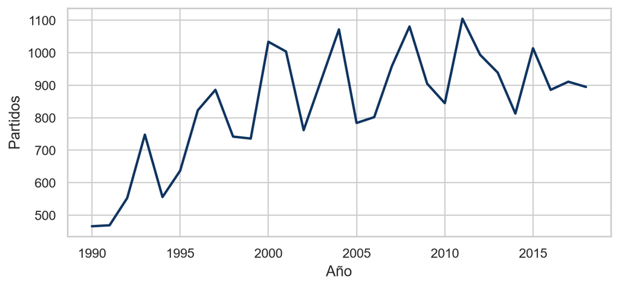

## La localía existe

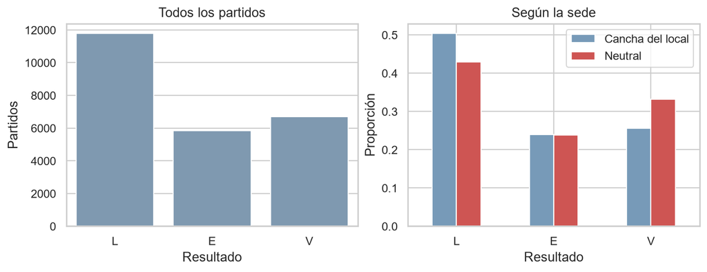

En cancha propia el local gana el **50%**. En cancha neutral, el **43%**.

Esos 7 puntos se los lleva casi enteros el visitante: pasa del 26% al 33%.

## Los goles, y un outlier

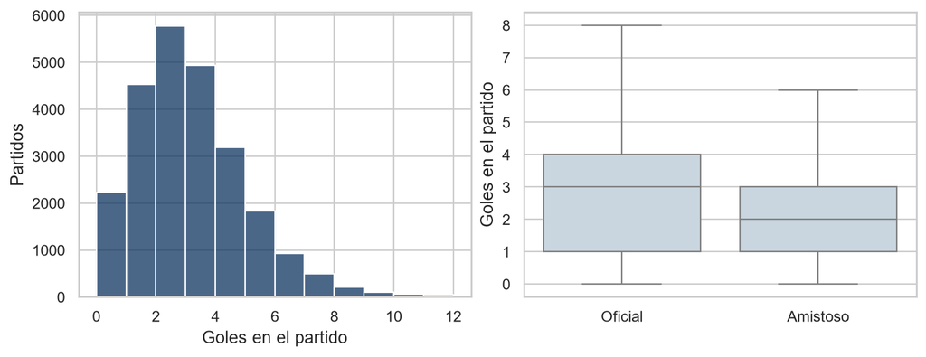

Lo normal son **2 goles**. El récord de la muestra es un **Australia 31 – 0 American Samoa** de 2001, por eliminatorias.

## La figura que lo explica todo

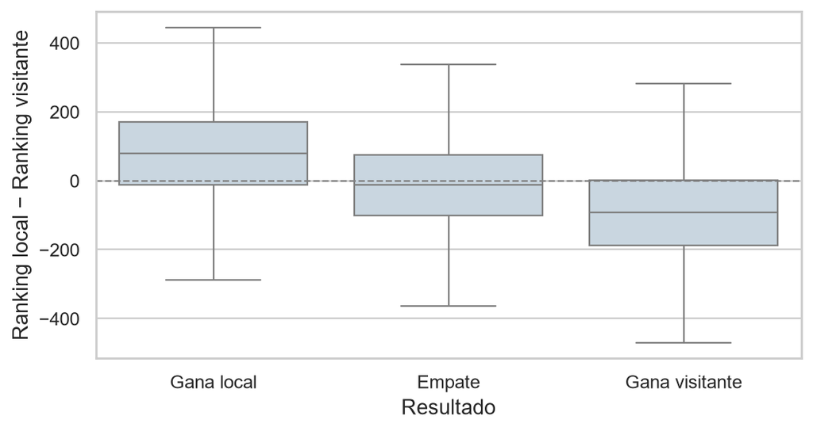

Gana el local: venía **+83** de ranking. Gana el visitante: **−102**. Empate: **−14**, justo en el medio.

## Uruguay

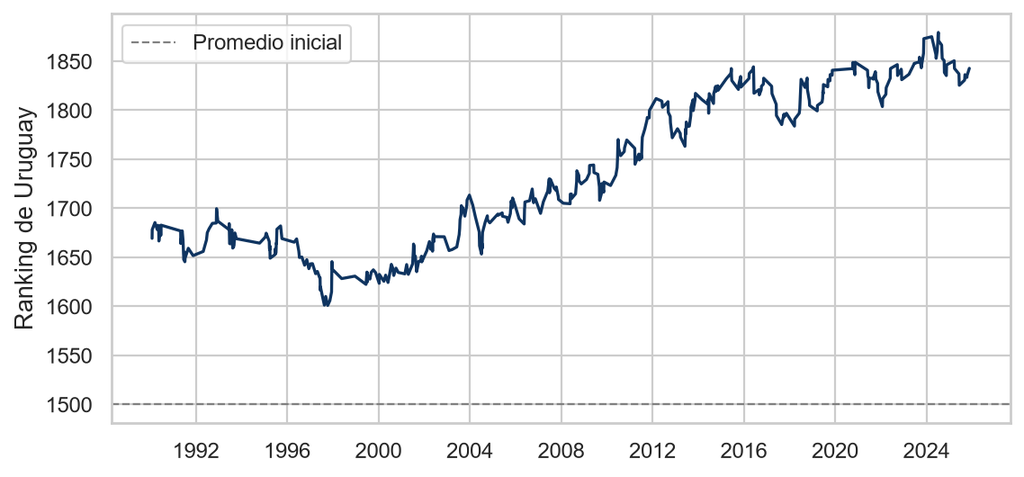

## Modelado

## Cortamos por fecha, no al azar

24.338entrenamiento · 1990–2018

6.839evaluación · 2019–2025

Si mezcláramos los años, el modelo podría **entrenar con 2020 para predecir 2010**.

Es justo lo contrario de lo que queremos.

## Tres modelos, del tonto al complejo

1**Referencia**  
Predecir siempre “gana el local”, sin mirar nada. El piso a superar.

2**Árbol de decisión**  
Preguntas de sí o no, tres niveles. Se puede dibujar y leer.

3**Random forest**  
200 árboles que votan. Más estable, menos interpretable.

Los hiperparámetros se eligen con validación cruzada **dentro del entrenamiento**, sin tocar los datos de evaluación.

## El árbol solo mira una cosa

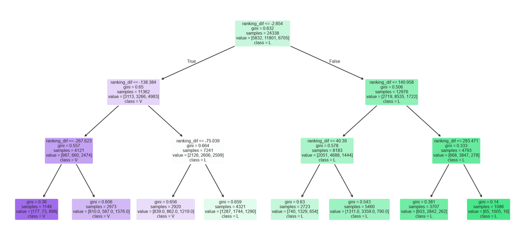

## Resultados

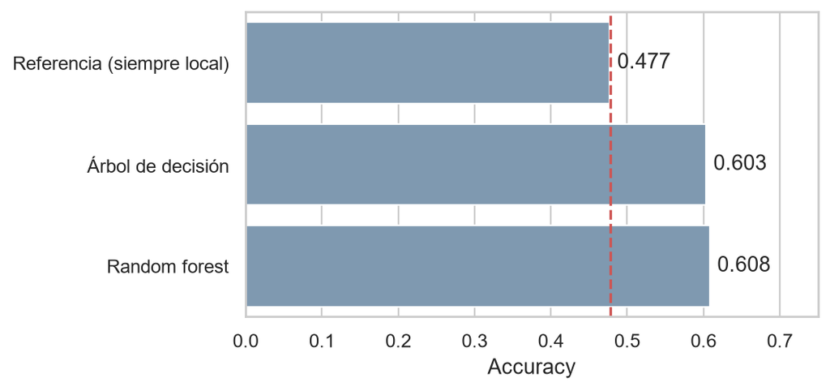

**+13 puntos porcentuales** sobre la referencia.

Entre el árbol y el bosque, casi nada: 0.603 contra 0.608.

## ¿Y quién hizo el trabajo?

| Variables | Accuracy |
| --- | --- |
| Referencia (siempre local) | 0.477 |
| Solo contexto (sede + amistoso) | 0.477 |
| Contexto + forma reciente, **sin ranking** | 0.540 |
| Solo `ranking_dif`, **una columna** | 0.604 |
| Todas las variables | 0.608 |

El contexto solo **no aporta nada**. El ranking solo es **casi todo el modelo**.

## Lo mismo, visto por el bosque

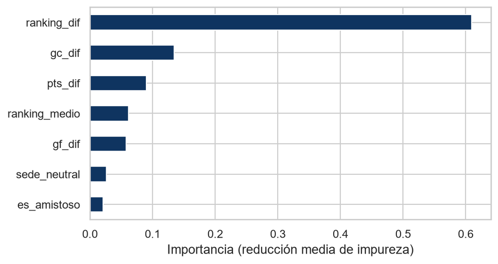

`ranking_dif` se lleva el **61%** de la importancia.

## Dónde falla

Y es más interesante que dónde acierta

## El empate es invisible

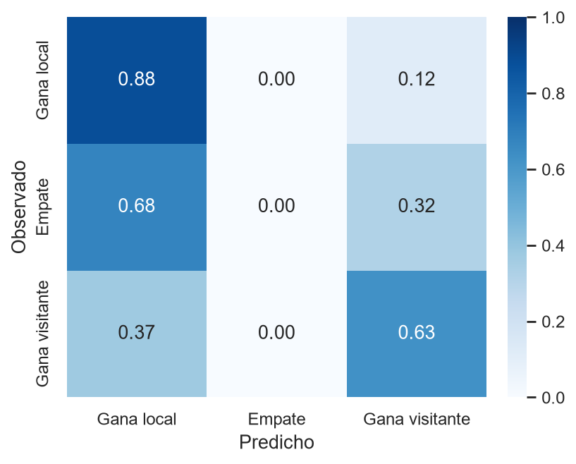

De **1555 empates**, el modelo detecta **6**. En 6839 partidos arriesga un empate 10 veces.

## Por qué, y no es culpa de los datos

~50%gana local

~24%empate

~26%gana visitante

El empate **nunca es la opción más probable**, ni en el partido más parejo.

Y el clasificador siempre elige la más probable. Así que nunca lo elige.

La salida: trabajar con **probabilidades** (`predict_proba`) en vez de forzar una única respuesta.

## Conclusiones

61%de acierto

48%la referencia

0.4%de los empates

- Sí se puede anticipar, **en parte**. Lo que importa es **quién viene siendo más fuerte**.
- La localía se mide: 50% en casa, 43% en cancha neutral.
- El modelo complejo no ganó nada. **Lo ganaron las variables.**
- Y falla justo en los partidos parejos, que son los interesantes.

## Gracias

Juan Apolo · Alen Cukier

github.com/juann1234/proyecto-final-python-cd